# Regression Analysis

5. Diagnosis & Variable Selection | Special Lecture for KINS

Boncho Ku, Ph.D. in Statistics

secondmoon@kiom.re.kr

Digital Health Research Division

Korea Institute of Oriental Medicine

2026-09-01

# Diagnosis & Variable Selection

## 요약통계량이 같은 네 자료

### 그림으로 보기

**앞 장에서 여기까지**: full model 적합과 계수 해석까지 마침. **이 장의 질문**: 이 모형을 믿어도 되는가, 변수를 다 남겨야 하는가

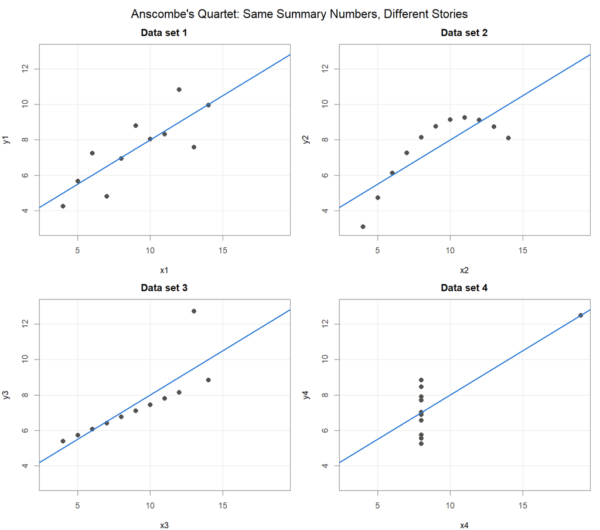

Anscombe’s quartet: four data sets with the same fitted line

서로 다른 네 자료에 최소제곱 직선을 적합하면 네 경우 모두 같은 직선이 나온다.

$$\hat y_i = 3.00 + 0.500\,x_i$$

**기호**

- $\hat y_i$: $i$번째 관측의 적합값, $x_i$: 설명변수 값
- $3.00$: 절편 추정값 $\hat\beta_0$, $0.500$: 기울기 추정값 $\hat\beta_1$
- 요약 숫자만으로는 네 자료를 구분할 수 없음
- 그림에서는 네 자료의 구조가 서로 전혀 다름 (Anscombe, 1973)
- 회귀분석은 계수 계산과 그림 확인을 함께 수행함

## 회귀모형의 네 가지 가정

### 정의

$$y_i = \beta_0 + \beta_1 x_{i1} + \cdots + \beta_p x_{ip} + \varepsilon_i, \qquad \varepsilon_i \overset{iid}{\sim} N(0,\ \sigma^2)$$

**기호**

- $y_i$: 반응변수, $x_{ij}$: $i$번째 관측의 $j$번째 설명변수
- $\beta_0,\dots,\beta_p$: 회귀계수, $\varepsilon_i$: 오차, $\sigma^2$: 오차의 분산
- $N(0,\sigma^2)$: 0을 중심으로 좌우대칭인 종 모양 분포
- $iid$: 오차들이 서로 영향을 주지 않으며(독립) 모두 같은 분포를 따름

**네 가지 가정**

- **선형성**: $x$와 $y$의 관계가 직선으로 표현됨
- **독립성**: 오차 $\varepsilon_i$끼리 서로 독립
- **정규성**: 오차가 정규분포 $N(0,\sigma^2)$을 따름
- **등분산성**: 오차의 분산이 어디서나 같은 $\sigma^2$

**Remark**

네 가정 중 하나라도 크게 위반되면 회귀계수의 표준오차(추정값이 자료가 바뀔 때마다 얼마나 흔들리는지를 나타내는 값), 유의성 검정, 신뢰구간이 모두 함께 흔들림 (Kutner et al., 2005)

## 잔차: 모형이 설명하지 못한 나머지

### 정의

$$e_i = y_i - \hat y_i, \qquad \mathbf e = \mathbf y - \hat{\mathbf y} = (\mathbf I - \mathbf H)\,\mathbf y$$

- $e_i$: 잔차, $y_i$: 관측값, $\hat y_i$: 적합값, $\mathbf I$: 단위행렬
- $\mathbf H = \mathbf X(\mathbf X^{\top}\mathbf X)^{-1}\mathbf X^{\top}$: 앞 장의 모자행렬. 적합값이 $\hat{\mathbf y}=\mathbf H\mathbf y$ 이므로, 잔차는 $\mathbf y$ 에서 $\mathbf H$ 가 설명한 부분을 뺀 나머지

**잔차의 역할**

- 오차 $\varepsilon_i$는 관측할 수 없으나 잔차 $e_i$는 자료에서 직접 계산됨
- 가정이 모두 성립하면 잔차는 0 주위에 **패턴 없이** 흩어짐
- 요약 숫자가 양호해도 잔차 그림에서 모형의 문제가 드러나기도 함

**잔차의 대수적 성질**

- $\mathbf M=\mathbf I-\mathbf H$ 도 대칭이고 멱등. $\mathbf M$: 잔차를 만들어 내는 행렬

$$\mathbf X^\top\mathbf e=\mathbf X^\top(\mathbf I-\mathbf H)\mathbf y=(\mathbf X^\top-\mathbf X^\top)\mathbf y=\mathbf 0
\;\Longrightarrow\;\sum_{i=1}^{n}e_i=0$$

$$E(\mathbf e)=\mathbf 0,\qquad \operatorname{Var}(\mathbf e)=\sigma^2(\mathbf I-\mathbf H)
\;\Longrightarrow\;\operatorname{Var}(e_i)=\sigma^2(1-h_{ii})$$

$$\operatorname{tr}(\mathbf I-\mathbf H)=n-(p+1)=30-4=26\;=\;\text{잔차의 자유도}$$

$\operatorname{Var}(e_i)$ 가 관측마다 다르므로, 잔차를 그대로 비교하지 않고 크기를 맞춘 **표준화잔차** $r_i=e_i/\big(\hat\sigma\sqrt{1-h_{ii}}\big)$ 를 사용

## 진단 그림 4종 읽는 법

### 그림으로 보기

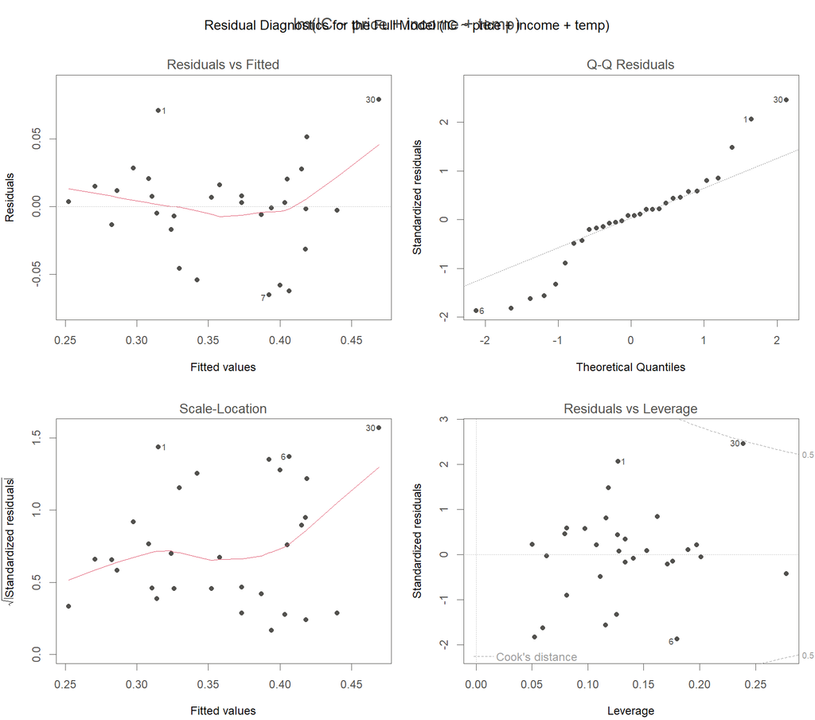

Residual diagnostics for the full model IC ~ price + income + temp

**읽는 법**

- **좌상 Residuals vs Fitted**: 곡선 패턴이 보이면 선형성 위반 신호
- **우상 Normal Q-Q**: 잔차를 크기순으로 늘어놓고 정규분포에서 기대되는 값과 짝지은 그림. 점들이 대각선에서 크게 벗어나면 정규성 의심
- **좌하 Scale-Location**: 오른쪽으로 갈수록 깔때기처럼 퍼지면 등분산성 위반
- **우하 Residuals vs Leverage**: 오른쪽 구석의 외딴 점은 영향점 후보

## 레버리지 $h_{ii}$

### 정의

레버리지 $h_{ii}$는 모자행렬 $\mathbf H$의 $i$번째 대각원소이며, $i$번째 관측이 설명변수 공간에서 얼마나 바깥에 놓여 있는지를 나타낸다.

$$\sum_{i=1}^{n} h_{ii} = \operatorname{tr}(\mathbf H) = p+1, \qquad \bar h = \frac{p+1}{n}$$

**기호**

- $\operatorname{tr}(\mathbf H)$: 대각원소의 합, $n$: 관측 수, $p$: 설명변수 개수
- $p+1$: 절편을 포함한 회귀계수의 개수
- 레버리지의 평균이 $(p+1)/n$ 으로 고정되므로, 이 값의 2배를 넘는 관측을 주목 대상으로 삼는 관례 (Kutner et al., 2005)

### 결과: full model

Leverage summary for the full model, n = 30

| Quantity | Value |
| --- | --- |
| $\operatorname{tr}(\mathbf H) = p+1$ | 4 |
| Average leverage $(p+1)/n$ | 0.133 |
| Rule of thumb $2(p+1)/n$ | 0.267 |
| Largest $h_{ii}$ (observation 9) | 0.278 |

## 스튜던트화 잔차

### 정의

잔차의 분산이 관측마다 다르므로 그대로 비교할 수 없다. 각자의 표준편차로 나눈 값이 **스튜던트화 잔차**다.

$$\operatorname{Var}(e_i)=\sigma^2(1-h_{ii}),\qquad r_i=\frac{e_i}{\hat\sigma\sqrt{1-h_{ii}}}$$

**기호**

- $e_i$: $i$번째 잔차, $h_{ii}$: 레버리지, $\hat\sigma$: 잔차 표준오차
- $r_i$: 스튜던트화 잔차. $E(r_i)=0$ 이지만 $\operatorname{Var}(r_i)$ 가 정확히 1은 아님
- 같은 값을 **표준화 잔차**라 부르는 문헌도 많음. 이름이 둘인 것이지 다른 값이 아님

**읽는 법**

- $-2\le r_i\le 2$ 안에 들고, 무늬가 없고, 퍼짐이 고르면 오차 가정을 만족한다고 봄
- 레버리지가 큰 관측일수록 $1-h_{ii}$ 가 작아, **같은 $e_i$ 라도 $r_i$ 가 커짐**. 시소 끝에 앉은 점의 이탈을 놓치지 않으려는 보정
- 정확히 정규분포를 따르지는 않으나 실무에서는 정규분포로 보고 판단

## 외적 스튜던트화 잔차

### $\hat\sigma$ 부풀림 문제

$i$번째 관측을 **빼고** 추정한 오차분산 $\hat\sigma_{(i)}^2$ 로 나눈 값을 **외적 스튜던트화 잔차**(스튜던트화 제외 잔차)라 한다.

$$t_i=\frac{e_i}{\hat\sigma_{(i)}\sqrt{1-h_{ii}}}$$

**기호**

- $\hat\sigma_{(i)}^2$: $i$번째 관측을 제외한 $n-1$개로 추정한 오차분산. 자유도는 $n-p-2$
- $t_i$: 외적 스튜던트화 잔차. 앞 슬라이드의 $r_i$ 와 분모만 다름

**왜 굳이 빼고 재는가**

- $\hat\sigma$ 는 **모든 관측으로** 계산되므로 이상점 자신이 $\hat\sigma$ 를 부풀림
- 부풀어난 분모로 나누면 자기 잔차가 작아 보임. 이상점이 **스스로를 감추는** 셈
- 자기를 빼고 만든 자로 재면 이 자기지시가 사라짐. 그래서 이상점 **검정**은 $r_i$ 가 아니라 $t_i$ 로 함

## 이상치, 레버리지, 영향점: 정의

### 세 용어의 구별

**이상치(outlier)**: $y$ 방향으로 동떨어진 점, 즉 잔차 $e_i$가 큰 관측

**레버리지(leverage)**: $x$ 방향으로 얼마나 끝자리에 있는지를 나타내는 값 $h_{ii}$

**영향점(influential point)**: 그 한 점을 제외하면 회귀직선이 크게 움직이는 점

### 핵심

- $y$ 방향의 이탈(큰 잔차)과 $x$ 방향의 이탈(큰 레버리지)이 **결합될 때** 회귀직선이 실제로 움직임
- 잔차만 크거나 레버리지만 큰 점은 직선을 크게 흔들지 못하는 경우가 있음
- 따라서 두 값은 따로 보지 않고 함께 평가함

## 이상치, 레버리지, 영향점: 그림 비교

### 점 하나를 더한 세 경우

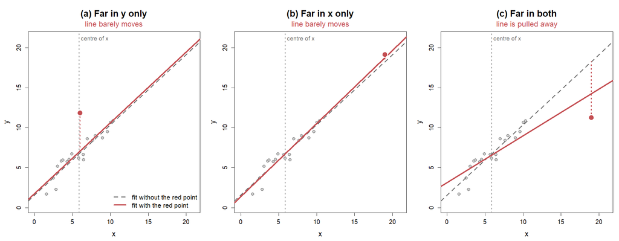

The same 20 points refitted three times, each with one extra point added (red). Dashed line: fit without it. Solid line: fit with it.

What moves the fitted line: not either deviation alone, but the two together

| 추가한 점 | $x$ 방향 이탈 (레버리지) | $y$ 방향 이탈 (잔차) | 직선이 움직이는가 |
| --- | --- | --- | --- |
| (a) 이상치 | 작음 | 큼 | 거의 그대로 |
| (b) 레버리지가 큰 점 | 큼 | 작음 | 거의 그대로 |
| (c) 영향점 | 큼 | 큼 | **크게 꺾임** |

- (b)와 (c)의 붉은 점은 $x$ 방향으로 **같은 자리**. 차이를 만든 것은 직선에서 벗어난 정도
- 잔차와 레버리지 중 하나만 커서는 직선이 흔들리지 않음. **둘이 겹칠 때만 영향점**

## 이상치, 레버리지, 영향점: Cook 거리

### 잔차와 레버리지의 결합

**정의와 기호**

$$D_i = \frac{r_i^{2}}{p+1}\cdot\frac{h_{ii}}{1-h_{ii}}$$

**기호**

- $r_i$: $i$번째 표준화잔차. 잔차 $e_i$ 를 그 표준오차로 나누어 서로 견줄 수 있게 만든 값
- $h_{ii}$: 레버리지, $p+1$: 절편을 포함한 회귀계수의 개수
- 두 요소가 곱해지므로 잔차와 레버리지가 함께 클 때 $D_i$ 가 특히 커짐 (Cook, 1977)

### 결과: full model

Largest diagnostic values in the full model, n = 30

| Diagnostic statistic | Largest value | Observation |
| --- | --- | --- |
| Standardized residual (absolute) | 2.46 | 30 |
| Leverage $h_{ii}$ | 0.278 | 9 |
| Cook’s distance $D_i$ | 0.475 | 30 |

Cook 거리 최댓값 0.475는 흔히 쓰는 기준값 1보다 작음: 한 관측이 결과를 좌우한다고 볼 근거는 없음

## 영향점 측도: DFFITS

### 정의

$i$번째 관측을 빼면 **그 관측의 적합값**이 얼마나 움직이는가를 표준화한 값

$$\mathrm{DFFITS}_i=\frac{\hat y_i-\hat y_{(i)}}{\hat\sigma_{(i)}\sqrt{h_{ii}}}
=t_i\sqrt{\frac{h_{ii}}{1-h_{ii}}}$$

**기호**

- $\hat y_{(i)}$: $i$번째를 빼고 적합한 모형이 주는 $i$번째 적합값
- $t_i$: 외적 스튜던트화 잔차, $h_{ii}$: 레버리지

**Cook 거리와의 관계**

- 두 측도 모두 **잔차 $\times$ 레버리지** 구조. 앞에서 본 두 요소가 함께 커야 값이 커진다는 성질이 같음
- 보는 대상이 다름: Cook 거리는 적합값 **$n$개 전체**가 움직인 양, DFFITS는 **그 관측 하나**의 적합값이 움직인 양
- 판정 기준: $|\mathrm{DFFITS}_i|>2\sqrt{(p+1)/n}$
- $h_{ii}$ 가 1에 가까우면 $\sqrt{h_{ii}/(1-h_{ii})}$ 가 발산. 레버리지가 극단이면 작은 잔차로도 값이 커짐

## 이상점 검정

### 제외 후 예측

1. **그 관측을 빼고 적합한다.** $i$번째를 제외한 $n-1$개로 $\hat{\boldsymbol\beta}_{(i)}$ 와 $\hat\sigma_{(i)}^2$ 을 구함. 자유도는 $n-p-2$
2. **뺀 관측을 예측한다.** $\hat y_{(i)}=\mathbf x_i^\top\hat{\boldsymbol\beta}_{(i)}$. 적합에 쓰이지 않았으므로 $y_i$ 와 서로 **독립**이며, 이 독립성이 다음 단계의 $t$분포를 성립시킴
3. **예측오차를 표준화한다.** $y_i$ 가 이상점이 아니라면 $E(y_i-\hat y_{(i)})=0$ 이므로
   $$t_i=\frac{y_i-\hat y_{(i)}}{\hat\sigma_{(i)}\sqrt{1+\mathbf x_i^\top(\mathbf X_{(i)}^\top\mathbf X_{(i)})^{-1}\mathbf x_i}}
   =\frac{e_i}{\hat\sigma_{(i)}\sqrt{1-h_{ii}}}\ \sim\ t(n-p-2)$$

$|t_i|\ge t_{\alpha/2,\,n-p-2}$ 이면 이상점으로 판정. 단, $n$개를 모두 검정하므로 유의수준을 $\alpha/n$ 으로 낮추는 **Bonferroni 보정**을 함께 씀

## 이상점: 유의점과 대처

### 함정과 절차

**검정을 그대로 믿으면 안 되는 네 경우**

- **이상점끼리 서로를 가림**: 두 개 이상이 이웃해 있으면 서로의 효과를 상쇄해 어느 쪽도 잡히지 않을 수 있음
- **모형이 바뀌면 이상점도 바뀜**: 어떤 모형에서의 이상점이 변수변환 뒤에는 이상점이 아닐 수 있음. **모형을 바꿀 때마다 이상점을 다시 조사**
- **정규분포가 아닐 때**: 오차 분포의 꼬리가 두꺼우면 큰 잔차가 나오는 것이 자연스러움. 이상점이 아니라 분포 특성일 수 있음
- **이상점이 무리를 이룰 때**: 큰 자료에서 한두 개는 문제가 되지 않지만, 그룹을 형성하면 모형 설정 자체를 의심해야 함

**이 순서로 확인**

1. **데이터 입력 오류를 검사한다.** 단위, 소수점, 자릿수 밀림처럼 기록 단계의 잘못인지 원자료와 대조
2. **그 관측이 나온 상황을 알아본다.** 그날의 장비 상태, 시료, 작업 조건처럼 표에 적히지 않은 사정을 확인
3. **제거하고 분석하되 반드시 밝힌다.** 어떤 관측을 왜 뺐는지를 결과에 함께 적음. **새 모형을 적합할 때는 뺐던 관측을 되돌려 넣고 다시 판단**
4. **실제로 가능한 값이면 제거하지 않는다.** 이상점을 포함한 채 견딜 수 있는 모형, 예를 들어 로버스트 회귀를 찾음

**주의**: 원인을 모르는 채 관측을 삭제하는 일은 금지. 결론이 한 점에 좌우되면 포함한 분석과 제외한 분석을 **둘 다 보고**

## 다중공선성과 VIF: 정의

### 설명변수 간 정보 중복

설명변수끼리 정보가 겹치는 현상을 다중공선성이라 하며, 이때 회귀계수 추정값 $\hat\beta_j$가 불안정해진다.

$$\mathrm{VIF}_j = \frac{1}{1-R_j^{2}}$$

**기호**

- $R_j^{2}$: $j$번째 설명변수를 **나머지 설명변수들로 회귀**했을 때의 결정계수, 곧 그 변수의 변동 중 나머지 변수들이 설명한 비율
- 겹침이 없으면 $R_j^{2}=0$ 이라 $\mathrm{VIF}_j=1$
- 겹침이 심해 $R_j^{2}$ 가 1에 가까워질수록 값이 급격히 증가

**판정 기준**

- 관례적으로 $\mathrm{VIF}_j$가 10, 문헌에 따라 5를 넘으면 심각한 다중공선성을 의심 (Kutner et al., 2005)

## 다중공선성과 VIF: 아이스크림 자료

### full model의 VIF

**VIF 표**

VIF for the full model IC ~ price + income + temp

| Variable | VIF |
| --- | --- |
| price | 1.03 |
| income | 1.14 |
| temp | 1.14 |

세 변수 모두 1에 가까움: 이 자료에서는 다중공선성 **문제 없음**

**계산 절차**

설명변수 하나를 나머지 설명변수로 회귀했을 때의 결정계수 $R_j^2$ 로 계산

$$\mathrm{VIF}_j=\frac{1}{1-R_j^2}$$

Derivation of the VIF values for the full model (n = 30)

| Regression | $R_j^2$ | $\mathrm{VIF}_j=1/(1-R_j^2)$ |
| --- | --- | --- |
| price on income, temp | 0.0331 | $1/0.967=1.03$ |
| income on price, temp | 0.126 | $1/0.874=1.14$ |
| temp on price, income | 0.125 | $1/0.875=1.14$ |

$R_j^2=0$ 이면 $\mathrm{VIF}_j=1$ 로 최솟값. $R_j^2\to 1$ 이면 분모가 0에 가까워져 $\mathrm{VIF}_j\to\infty$

## 진단 후 처방

### 실무 적용

Diagnostic signals and corresponding remedies

| Diagnostic signal | Suspected violation | Remedy |
| --- | --- | --- |
| 잔차 그림의 곡선 패턴 | 선형성 | 변수 변환($\log$, 제곱근) 또는 곡선 항 추가 |
| 잔차 퍼짐의 깔때기 모양 | 등분산성 | 가중회귀로 보정: Weighted Regression 장에서 다룸 |
| Q-Q 그림에서 대각선 이탈 | 정규성 | 반응변수 변환 검토 |
| 유난히 큰 Cook 거리 | 특정 관측의 과도한 영향 | 원자료 확인 후 민감도 분석 |

### 관련 슬라이드

- 이상 관측의 처리 절차는 앞의 **이상점: 유의점과 대처** 슬라이드에 정리
- 표의 **Remedy** 열에 있는 변수 변환은 이어지는 네 슬라이드에서 하나씩 펼침
- 가중회귀는 Weighted Regression 장이 통째로 담당

## 잔차그림과 가정 위반

### 여섯 가지 유형

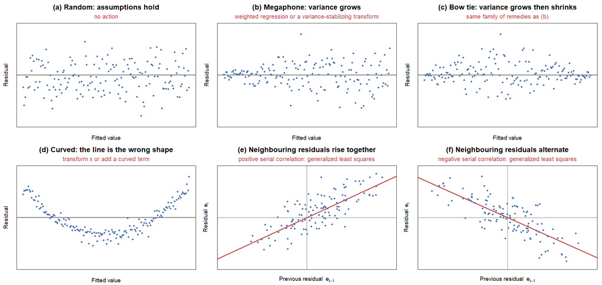

Six residual shapes and what each one accuses the model of. Panels (a) to (d) plot residuals against the fitted value; (e) and (f) are lag plots, each residual against the one before it.

- 세로축은 **스튜던트화 잔차**. (a)~(d)의 가로축은 적합값 $\hat y_i$ 이고, 가정이 성립하면 (a)처럼 0을 중심으로 무늬 없이 흩어져야 함
- (e)~(f)는 **시차산점도**. 점 하나가 이웃한 잔차 한 쌍 $(e_{t-1},\,e_t)$ 이고, 구름이 기운 방향이 **잔차 간 상관의 부호**. 기울기는 1차 자기상관계수 $r_1$ (가중회귀 장의 Durbin-Watson 통계량이 요약하는 값). 자료가 모인 **순서**가 있어야 그릴 수 있음
- 자기상관은 잔차 대 적합값 그림에서 **볼 수 없음**. 최소제곱에서 $\mathbf e^\top\hat{\mathbf y}=\mathbf y^\top(\mathbf I-\mathbf H)\mathbf H\mathbf y=0$ 이므로 $\operatorname{cor}(e,\hat y)=0$ 이 자료와 무관하게 항상 성립
- 설명변수마다 같은 그림을 따로 그려 보면 **어느 변수가 원인인지** 좁힐 수 있음

## 보정 1: Box-Cox 변환

### 거듭제곱의 선택

**Box-Cox 변환**: 반응변수를 아래 형태로 바꾸어, 변환 뒤의 오차가 정규분포에 가까워지도록 하는 $\lambda$ 를 찾는다.

$$y^{(\lambda)}=\begin{cases}\dfrac{y^{\lambda}-1}{\lambda}, & \lambda\neq 0\\[4pt] \ln y, & \lambda=0\end{cases}$$

**기호**

- $\lambda$: 찾아야 할 하나의 상수. $\lambda=1$ 이면 변환하지 않은 것과 같고, $\lambda=0.5$ 는 제곱근, $\lambda=0$ 은 로그
- $y>0$ 이어야 함. 0이나 음수가 있으면 상수를 더한 뒤 적용

**$\lambda$ 를 정하는 법**

- 각 $\lambda$ 마다 변환 후 모형의 **로그가능도** $L(\lambda)$ 를 계산해 가장 큰 값을 주는 $\hat\lambda$ 를 택함
- $95\%$ 신뢰구간은 $\{\lambda:\ L(\lambda)>L(\hat\lambda)-\tfrac{1}{2}\chi^2_{0.95,\,1}\}$. 구간 안에 $1$ 이 들어 있으면 **변환할 근거가 없음**
- $H_0:\lambda=\lambda_0$ 검정은 $2\{L(\hat\lambda)-L(\lambda_0)\}\ \sim\ \chi^2(1)$

**주의**: 반응변수를 변환하면 계수의 뜻이 원래 단위에서 벗어나 **해석이 어려워짐**. 구간 안에 $0.5$, $0$, $1$ 같은 값이 있으면 $\hat\lambda$ 대신 그 값을 쓰는 편이 설명하기 쉬움

## 보정 1: Box-Cox 적용 예

### Galapagos 자료: 종 수 모형

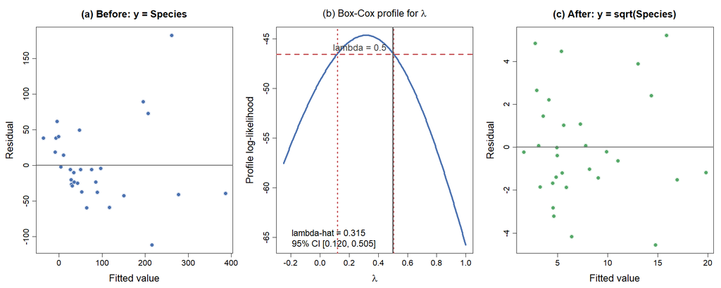

(a) Residuals against fitted values on the raw response. (b) Profile log-likelihood over lambda with its 95% interval. (c) Residuals after the square-root transform.

Galapagos species data (n = 30). $\hat\lambda=0.315$, 95% CI $[0.120,\ 0.505]$: 1 is outside, 0.5 is inside at the boundary.

| Check | $y=\text{Species}$ | $y=\sqrt{\text{Species}}$ |
| --- | --- | --- |
| $R^2$ | 0.766 | 0.783 |
| 잔차 정규성 $p$ (Shapiro-Wilk) | **0.018** | 0.287 |
| 등분산 $p$ (Breusch-Pagan) | 0.081 | 0.246 |
| 잔차 표준편차의 비 (적합값 상위 절반 / 하위 절반) | **2.32** | 1.08 |

## 보정 2: 분산안정화 변환

### 분산과 평균의 관계

**유도**

$\mu=E(y)$ 이고 분산이 평균의 함수 $\operatorname{Var}(y)=g(\mu)$ 라 하자. 함수 $h$ 를 씌운 뒤의 분산을 델타법으로 근사하면

$$\operatorname{Var}\{h(y)\}\ \approx\ \{h'(\mu)\}^2\,g(\mu)$$

이 값이 $\mu$ 와 무관해지려면 $h'(\mu)\propto 1/\sqrt{g(\mu)}$, 곧 $h(\mu)=\displaystyle\int \frac{d\mu}{\sqrt{g(\mu)}}$

Variance-stabilizing transformations, each obtained from the integral above

| $\operatorname{Var}(y)$ | 변환 $h(y)$ | 적용 상황 |
| --- | --- | --- |
| $\propto\mu$ | $\sqrt{y}$ | 분산이 기댓값에 비례. 계수 자료 |
| $\propto\mu$, $y$ 에 0 존재 | $\sqrt{y}+\sqrt{y+1}$ | 값이 0이거나 0에 가까운 경우 |
| $\propto\mu^2$ | $\ln y$ | **가장 많이 쓰임**. $y$ 의 범위가 큰 경우 |
| $\propto\mu^2$, $y$ 에 0 존재 | $\ln(y+1)$ | 0이 존재하는 경우 |
| $\propto\mu^3$ | $y^{-1/2}$ | 작은 값을 많이 갖는 경우 |
| $\propto\mu(1-\mu)$ | $\arcsin\sqrt{y}$ | $y$ 가 비율인 경우 |

가중회귀(Weighted Regression 장)와 이 표는 **같은 문제에 대한 두 처방**. 분산 구조를 알면 가중치로, 모르면 변환으로 대응

## 보정 3: 선형화 변환

### 곡선을 직선으로

Linearizing transformations. Multiple regression extends each row by adding the remaining terms.

| 원래 형태 | 변환 | 선형모형 |
| --- | --- | --- |
| $y=\beta_0\,x^{\beta_1}\varepsilon$ | 양변에 $\ln$ | $\ln y=\ln\beta_0+\beta_1\ln x+\ln\varepsilon$ |
| $y=\beta_0\,e^{\beta_1 x}\varepsilon$ | 양변에 $\ln$ | $\ln y=\ln\beta_0+\beta_1 x+\ln\varepsilon$ |
| $y=\beta_0+\beta_1\ln x+\varepsilon$ | $x$ 만 $\ln$ | $y=\beta_0+\beta_1 x^{*}+\varepsilon$, $x^{*}=\ln x$ |
| $y=\dfrac{1}{\beta_0+\beta_1 x+\varepsilon}$ | 양변의 역수 | $y^{*}=\beta_0+\beta_1 x+\varepsilon$, $y^{*}=1/y$ |

**주의**

- 위 첫 두 줄은 오차가 **곱셈형**($y=f(x)\cdot\varepsilon$)일 때만 로그 후 덧셈형이 됨. 덧셈형 오차 $y=f(x)+\varepsilon$ 에 로그를 씌우면 오차 구조가 바뀜
- 설명변수만 변환하면 계수 해석이 그대로 남지만, **반응변수를 변환하면 원래 단위의 뜻이 사라짐**
- 변환 뒤에는 잔차그림과 이상점 조사를 **처음부터 다시** 수행

## 변수선택의 필요성

### 정의

**과적합(overfitting)**: 자료에 들어 있는 우연한 변동인 잡음까지 모형이 반영하여, 지금 가진 자료에는 잘 맞지만 새로운 자료의 예측에는 실패하는 현상.

### 주의: $R^2$ 비교의 한계

설명변수를 추가하면 결정계수 $R^{2}$, 곧 반응변수의 변동 중 모형이 설명한 비율은 **절대 감소하지 않음**. $R^{2}$ 만 보면 변수를 모두 포함한 모형이 언제나 우수해 보이며, 이것이 설명변수를 모두 포함하려는 잘못된 판단의 원인 (Kutner et al., 2005)

### 정리

- 필요한 것은 모수 개수만큼 **벌점을 부과하는 모형 선택 기준**
- 대표적인 기준: 수정 $R^{2}$, AIC

## 모형 선택 기준: AIC의 정의

### 적합도와 벌점

**AIC (Akaike Information Criterion)**: 모형의 적합도 항과 모수 개수에 매기는 벌점 항을 더한 모형 선택 기준. 같은 자료로 적합한 모형들 사이에서 값이 **작을수록 선호**된다 (Akaike, 1974).

$$\mathrm{AIC} = -2\log\hat L + 2k$$

**기호**

- $\hat L$: 적합한 모형이 지금의 자료를 얼마나 그럴듯하게 만들어 내는지를 나타내는 값(최대가능도). 잘 맞을수록 증가
- $\log$: 자연로그
- $k$: 추정하는 모수의 개수. 회귀계수 $p+1$개에 오차분산 $\sigma^{2}$ 하나를 더한 $p+2$

## AIC의 두 항 읽기

### 두 항의 상충

- 앞항 $-2\log\hat L$: **적합도** 부분으로, 자료에 잘 맞을수록 작아짐
- 뒷항 $2k$: **벌점** 부분으로, 추정하는 모수가 하나 늘 때마다 2가 더해짐
- 변수를 추가하면 앞항은 줄고 뒷항은 늘어남: 두 항의 합이 작은 모형이 균형이 좋은 모형

### 주의

AIC의 절댓값 자체에는 의미가 없음. 같은 자료로 적합한 모형들 사이의 **상대적 크기**만 의미를 가지므로 값이 음수여도 무방. 수정 $R^{2}$ 도 변수 개수를 반영해 $R^{2}$ 를 깎는다는 점에서 같은 취지의 지표

## 아이스크림 자료: 후보 모형 비교

### 결과

**결과**

Candidate models for the ice cream data, n = 30

| Model | Predictors | $R^2$ | Adjusted $R^2$ | AIC |
| --- | --- | --- | --- | --- |
| $M_1$ (full) | price, income, temp | 0.719 | 0.686 | -107.21 |
| $M_2$ | income, temp | 0.702 | 0.680 | **-107.48** |
| $M_3$ | temp | 0.602 | 0.587 | -100.77 |

**AIC 계산**

오차가 정규분포를 따르면 최대가능도가 잔차제곱합만의 함수가 되어 다음과 같이 정리됨

$$\mathrm{AIC}=-2\ln\hat L+2k=n\ln\!\Big(\frac{\mathrm{SSE}}{n}\Big)+2k+n\{1+\ln 2\pi\}$$

**기호**

- $k$: 추정한 모수의 개수(회귀계수 $p+1$ 개와 $\sigma^2$ 하나를 합해 $k=p+2$)
- $n\{1+\ln 2\pi\}=85.136$: 모형에 무관한 상수

$$\mathrm{AIC}(M_1)=30\ln\frac{0.0353}{30}+2\times 5+85.136=-202.35+10+85.136=-107.21$$

$$\mathrm{AIC}(M_2)=30\ln\frac{0.0374}{30}+2\times 4+85.136=-200.62+8+85.136=-107.48$$

**판단**: $R^2$ 는 full 모형이 가장 크지만 AIC 최솟값은 `IC ~ income + temp`. full 모형의 `price` 계수는 p-value가 0.226으로, 효과가 없다고 가정했을 때 이 정도 결과가 우연히 나올 확률이 작지 않음. 두 근거를 함께 보아 `price` 를 제외

## 후진제거법: 탐색 경로

### 한 번에 하나씩 제거

완전모형에서 출발하여 변수를 하나씩 제거해 보고, AIC가 가장 작아지는 방향으로 한 걸음씩 이동

**탐색 경로**

Backward elimination path by AIC on the ice cream data

| Candidate | $\mathrm{AIC}^{*}$ | Decision |
| --- | --- | --- |
| 출발점: price, income, temp | -194.34 | starting point |
| price 제거 | -194.62 | smaller: price 제외 |
| income 제거 | -188.31 | larger: income 유지 |
| temp 제거 | -160.31 | larger: temp 유지 |

**두 AIC 눈금의 관계**

탐색에는 상수를 뺀 간이 정의를 쓰기도 함

$$\mathrm{AIC}^{*}=n\ln\!\Big(\frac{\mathrm{SSE}}{n}\Big)+2(p+1),\qquad
\mathrm{AIC}-\mathrm{AIC}^{*}=2+n\{1+\ln 2\pi\}=87.136$$

절댓값은 다르지만 상수를 더한 것뿐이므로 **모형 간 차이는 동일**

$$-194.62-(-194.34)=-0.28,\qquad -107.48-(-107.21)=-0.27$$

두 값의 차이는 표에 적은 반올림 자릿수 때문. AIC는 절댓값이 아니라 모형 사이의 차이로만 읽음

**결과**: price 제외, income 과 temp 는 유지. 앞 슬라이드의 수동 비교와 같은 결론

## 선택 후 재진단

### 그림으로 확인

선택된 축소 모형식

$$\hat y_i = -0.113 + 0.00353\,x_{i2} + 0.00354\,x_{i3}$$

**기호**

- $x_{i2}$: 소득, $x_{i3}$: 온도
- $R^2 = 0.702$, 수정 $R^2 = 0.680$

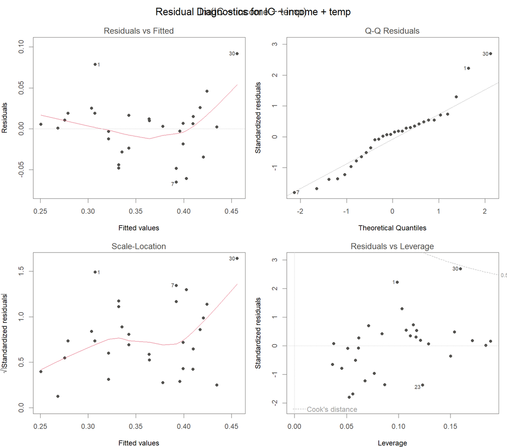

Residual diagnostics for the selected model

- 변수선택으로 모형이 바뀌면 잔차도 바뀜
- 따라서 선택된 모형에 대해 진단을 **다시** 수행함
- 진단과 선택은 한 번에 끝내는 순서가 아니라 **순환**하는 과정

## 자동 선택의 한계

### 주의

- 자동 탐색은 **후보를 제안**할 뿐이며 최종 결정은 연구자의 몫
- **도메인 지식이 우선**: 이론상 반드시 필요한 변수는 정보기준 값만으로 제외하지 않음
- 같은 자료를 여러 번 들여다보며 모형을 고른 뒤 계산한 p-value와 신뢰구간은 **그대로 신뢰하기 어려움**. 선택 과정 자체가 결과에 유리한 쪽으로 작용하기 때문
- 선택된 모형의 성능을 정직하게 평가하려면 **선택에 쓰지 않은 자료**가 필요함

## 실무 적용: 방사선 선량-반응 모형 선택

### 원폭 생존자 수명연구(LSS)

- 포아송 회귀로 1 Gy당 **초과상대위험**(excess relative risk, ERR)을 추정. 방사선방호 선량한도의 근거 자료
- 고형암 발생 1958~2009년 자료: 대상 105,444명, 고형암 22,538건, 3.1백만 인년

Dose-response model selected for each sex in the Life Span Study

| 집단 | 가장 잘 맞는 모형 | 1 Gy 에서의 ERR | 95% 신뢰구간 |
| --- | --- | --- | --- |
| 여성 | 선형 | 0.64 /Gy | 0.52 ~ 0.77 |
| 남성 | 선형-이차 | 0.20 | 0.12 ~ 0.28 |

- **같은 자료, 같은 반응변수인데 집단을 나누면 세워야 할 모형이 달라짐**
- 어느 모형을 고를 것인가가 이 장의 주제. 적합도만으로 정할 수 없고 진단과 정보기준을 함께 봄
- 선량한도라는 규제 값이 이 선택에 걸려 있음. 모형 선택이 행정 결정으로 이어지는 사례

*Carcinogenesis* (2025), “Summary of radiation effects on incidence of solid cancers in the Life Span Study of atomic bomb survivors: 1958-2009”.

## 이 장의 정리

### Diagnosis & Variable Selection

진단은 모형이 자료와 맞는지 확인하는 절차이고, 변수선택은 설명력과 단순함의 균형점을 찾는 절차이며, 두 절차는 번갈아 반복된다.

**이 장의 도구**

- 가정 네 가지: 선형성, 독립성, 정규성, 등분산성
- 진단: 잔차 $e_i$, 진단 그림 4종, 레버리지 $h_{ii}$, Cook 거리 $D_i$, VIF
- 선택: $\mathrm{AIC} = -2\log\hat L + 2k$, 수정 $R^2$, 후진제거법
- 아이스크림 자료의 결론: `IC ~ income + temp`

**다음 장**: Weighted Regression: 진단에서 잔차가 깔때기 모양으로 퍼졌을 때, 곧 등분산이 깨졌을 때의 처방

## 참고문헌

### 이 장에서 인용한 문헌

- Anscombe, F. J. (1973). Graphs in statistical analysis. *The American Statistician*, 27(1), 17-21.
- Cook, R. D. (1977). Detection of influential observation in linear regression. *Technometrics*, 19(1), 15-18.
- Akaike, H. (1974). A new look at the statistical model identification. *IEEE Transactions on Automatic Control*, 19(6), 716-723.
- Kutner, M. H., et al. (2005). *Applied Linear Statistical Models*, 5th ed. McGraw-Hill. (진단 기준값, 과적합)
- Box, G. E. P., & Cox, D. R. (1964). An analysis of transformations. *Journal of the Royal Statistical Society B*, 26(2), 211-252.
- 충남대학교 강의노트 *제5장. 회귀진단 및 보정*. (이 장의 구성, 이상점 검정과 유의점, 보정 방법의 분류, 예제 5.2 Galapagos 자료)
- Johnson, M. P., & Raven, P. H. (1973). Species number and endemism: the Galapagos Archipelago revisited. *Science*, 179(4076), 893-895. (Galapagos 자료의 원 출처)

### 교과서

- Kutner, M. H., Nachtsheim, C. J., Neter, J., & Li, W. (2005). *Applied Linear Statistical Models*, 5th ed. McGraw-Hill.
- Faraway, J. J. (2015). *Linear Models with R*, 2nd ed. CRC Press.